# Practical Machine Learning Course Notes

### R Commands and Examples

- `rf<-train(outcome ~ ., data=train, method="rf", prox=TRUE, ntree=500)` = runs random forest algorithm on the training data against all predictors
  - **Note**: random forest algorithm automatically bootstrap by default, but it is still important to have train/test/validation split to verify the accuracy of the model
  - `prox=TRUE` = the proximity measures between observations should be calculated (used in functions such as `classCenter()` to find center of groups)
    - `rf$finalModel$prox` = returns matrix of proximities
  - `ntree=500` = specify number of trees that should be constructed
  - `do.trace=TRUE` = prints logs as the trees are being built $\rightarrow$ useful by indicating progress to user
  - **Note**: `randomForest()` function can be used to perform random forest algorithm (syntax is the same as `train`) and is much faster
- `getTree(rf$finalModel, k=2)` = return specific tree from random forest model
- `classCenters(predictors, outcome, proximity, nNbr)` = return computes the cluster centers using the `nNbr` nearest neighbors of the observations
  - `prox = rf$finalModel$prox` = proximity matrix from the random forest model
  - `nNbr` = number of nearest neighbors that should be used to compute cluster centers
- `predict(rf, test)` = apply the random forest model to test data set
  - `confusionMatrix(predictions, actualOutcome)` = tabulates the predictions of the model against the truths
    - **Note**: this is generally done for the validation data set using the model built from training
- *example*

```r
# load data
data(iris)
# create train/test data sets
inTrain <- createDataPartition(y=iris$Species,p=0.7, list=FALSE)
training <- iris[inTrain,]
testing <- iris[-inTrain,]
# apply random forest
modFit <- train(Species~ .,data=training,method="rf",prox=TRUE)
# return the second tree (first 6 rows)
head(getTree(modFit$finalModel,k=2))
```

```
##   left daughter right daughter split var split point status prediction
## 1             2              3         4        0.75      1          0
## 2             0              0         0        0.00     -1          1
## 3             4              5         3        4.75      1          0
## 4             0              0         0        0.00     -1          2
## 5             6              7         1        6.05      1          0
## 6             8              9         4        1.75      1          0
```

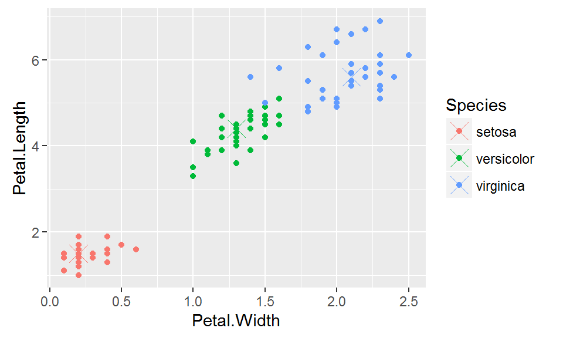

```r
# compute cluster centers
irisP <- classCenter(training[,c(3,4)], training$Species, modFit$finalModel$prox)
# convert irisP to data frame and add Species column
irisP <- as.data.frame(irisP); irisP$Species <- rownames(irisP)
# plot data points
p <- qplot(Petal.Width, Petal.Length, col=Species,data=training)
# add the cluster centers
p + geom_point(aes(x=Petal.Width,y=Petal.Length,col=Species),size=5,shape=4,data=irisP)
```

```r
# predict outcome for test data set using the random forest model
pred <- predict(modFit,testing)
# logic value for whether or not the rf algorithm predicted correctly
testing$predRight <- pred==testing$Species
# tabulate results
table(pred,testing$Species)
```

```
##
## pred         setosa versicolor virginica
##   setosa         15          0         0
##   versicolor      0         13         2
##   virginica       0          2        13
```

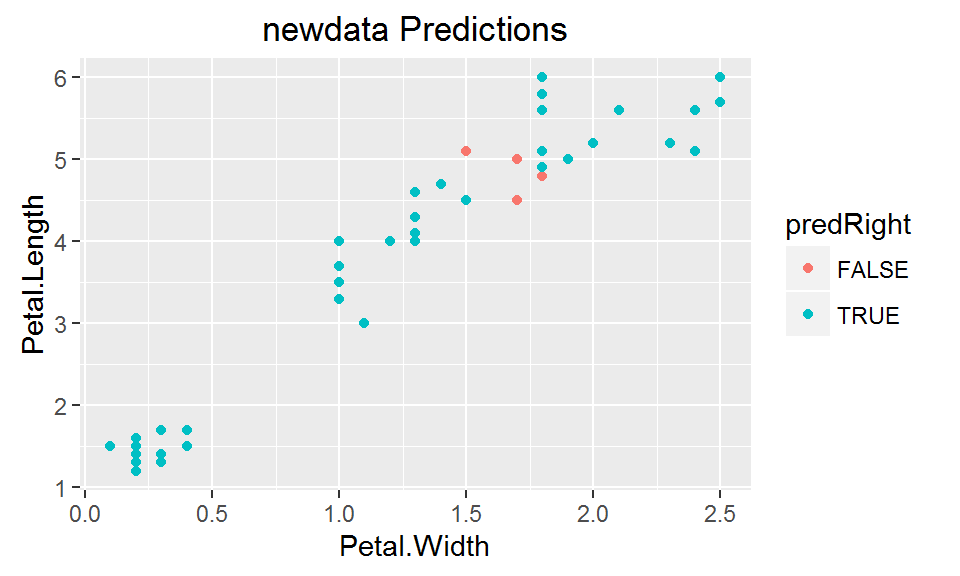

```r
# plot data points with the incorrect classification highlighted
qplot(Petal.Width,Petal.Length,colour=predRight,data=testing,main="newdata Predictions")
```

$\pagebreak$

## Boosting

- **boosting** = one of the most widely used and accurate prediction models, along with random forest
- boosting can be done with any set of classifiers, and a well-known approach is [gradient boosting](http://en.wikipedia.org/wiki/Gradient_boosting)
- more detail tutorial can be found [here](http://webee.technion.ac.il/people/rmeir/BoostingTutorial.pdf)
- **process**: take a group of weak predictors $\rightarrow$ weight them and add them up $\rightarrow$ result in a stronger predictor
  - start with a set of classifiers $h_1, \ldots, h_k$
    - examples: all possible trees, all possible regression models, all possible cutoffs (divide data into different parts)
  - calculate a weighted sum of classifiers as the prediction value
    $$f(x) = \sum_i \alpha_i h_i(x)$$
    where $\alpha_i$ = coefficient/weight and $h_i(x)$ = value of classifier
    - goal = minimize error (on training set)
    - select one $h$ at each step (iterative)
    - calculate weights based on errors
    - up-weight missed classifications and select next $h$
- *example*

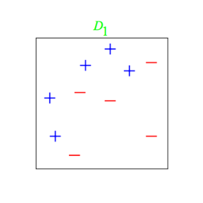

- we start with space with **blue +** and **red -** and the goal is to classify all the object correctly
- only straight lines will be used for classification

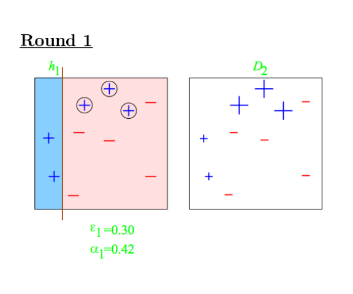

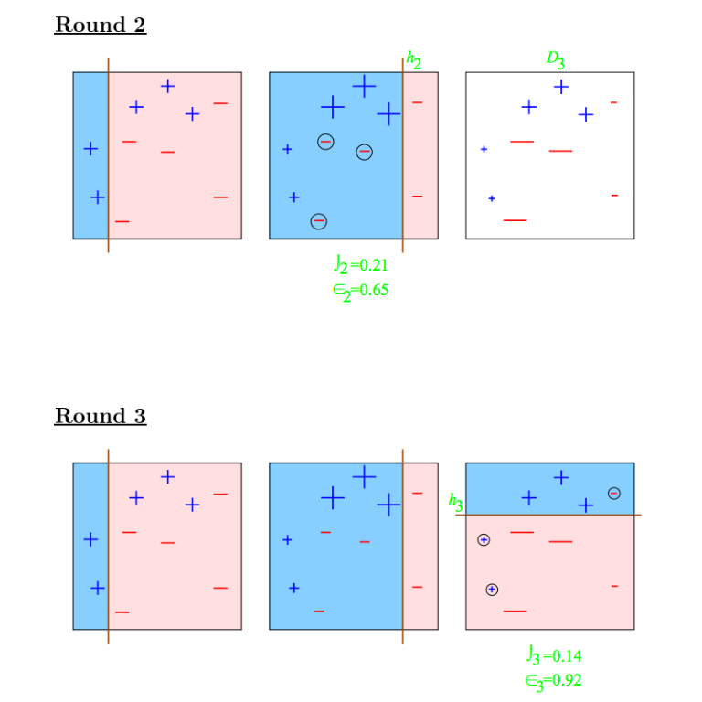

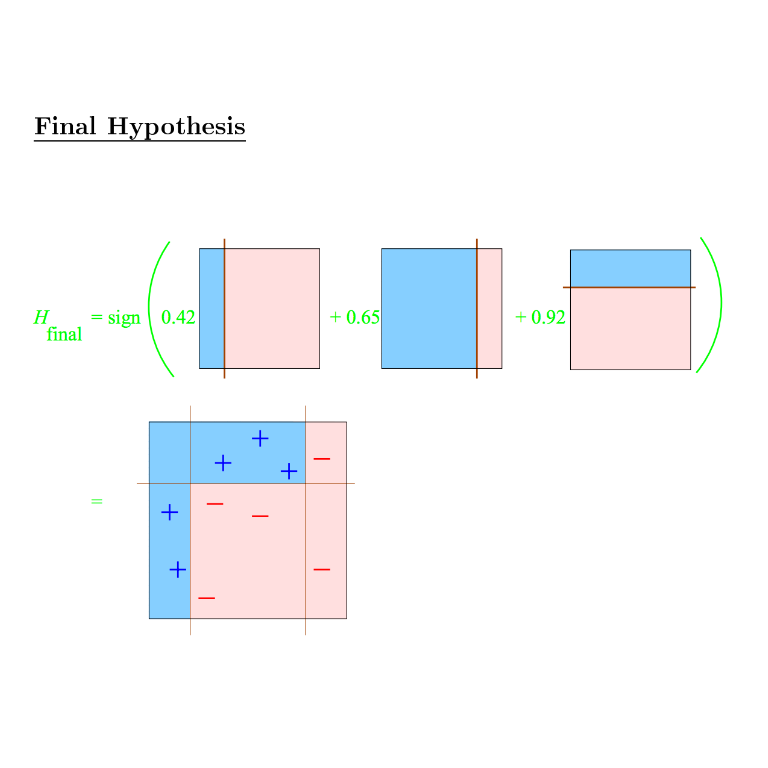

- from the above, we can see that a group of weak predictors (lines in this case), can be combined and weighed to become a much stronger predictor

### R Commands and Examples

- `gbm <- train(outcome ~ variables, method="gbm", data=train, verbose=F)` = run boosting model on the given data
  - options for `method` for boosting
    - [`gbm`](http://cran.r-project.org/web/packages/gbm/index.html) - boosting with trees
    - [`mboost`](http://cran.r-project.org/web/packages/mboost/index.html) - model based boosting
    - [`ada`](http://cran.r-project.org/web/packages/ada/index.html) - statistical boosting based on [additive logistic regression](http://projecteuclid.org/DPubS?service=UI&version=1.0&verb=Display&handle=euclid.aos/1016218223)
    - [`gamBoost`](http://cran.r-project.org/web/packages/GAMBoost/index.html) for boosting generalized additive models
    - **Note**: differences between packages include the choice of basic classification functions and combination rules
- `predict` function can be used to apply the model to test data, similar to the rest of the algorithms in `caret` package
- *example*

```r
# load data
data(Wage)
# remove log wage variable (we are trying to predict wage)
Wage <- subset(Wage,select=-c(logwage))
# create train/test data sets
inTrain <- createDataPartition(y=Wage$wage,p=0.7, list=FALSE)
training <- Wage[inTrain,]; testing <- Wage[-inTrain,]
# run the gbm model
modFit <- train(wage ~ ., method="gbm",data=training,verbose=FALSE)
# print model summary
print(modFit)
```

```
## Stochastic Gradient Boosting
##
## 2102 samples
##   10 predictor
##
## No pre-processing
## Resampling: Bootstrapped (25 reps)
## Summary of sample sizes: 2102, 2102, 2102, 2102, 2102, 2102, ...
## Resampling results across tuning parameters:
##
##   interaction.depth  n.trees  RMSE      Rsquared   RMSE SD   Rsquared SD
##   1                   50      35.66577  0.2999192  1.575565  0.02337561
##   1                  100      35.11476  0.3111799  1.481016  0.02157929
##   1                  150      35.02718  0.3137694  1.438008  0.02062790
##   2                   50      35.04157  0.3148807  1.500431  0.02285973
##   2                  100      34.88069  0.3195858  1.452622  0.02054340
##   2                  150      34.93116  0.3181132  1.448111  0.01943547
##   3                   50      34.88720  0.3196563  1.479245  0.02258544
##   3                  100      34.95639  0.3172195  1.451944  0.02100039
##   3                  150      35.16021  0.3111064  1.447594  0.02022995
##
## Tuning parameter 'shrinkage' was held constant at a value of 0.1
##
## Tuning parameter 'n.minobsinnode' was held constant at a value of 10
## RMSE was used to select the optimal model using  the smallest value.
## The final values used for the model were n.trees = 100,
##  interaction.depth = 2, shrinkage = 0.1 and n.minobsinnode = 10.
```

$\pagebreak$

## Model Based Prediction

- **model based prediction** = assumes the data follow a probabilistic model/distribution and use *Bayes’ theorem* to identify optimal classifiers/variables
  - can potentially take advantage of structure of the data
  - could help reduce computational complexity (reduce variables)
  - can be reasonably accurate on real problems
- this approach does make **additional assumptions** about the data, which can lead to model failure/reduced accuracy if they are too far off
- *goal* = build parameter-based model (based on probabilities) for conditional distribution $P(Y = k~|~X = x)$, or the probability of the outcome $Y$ is equal to a particular value $k$ given a specific set of predictor variables $x$
  - **Note**: $X$ is the data for the model (observations for all predictor variables), which is also known as the **design matrix**
- **typical approach/process**
  1. start with the quantity $P(Y = k~|~X = x)$
  2. apply *Bayes’ Theorem* such that
     $$P(Y = k ~|~ X=x) = \frac{P(X=x~|~Y=k)P(Y=k)}{\sum_{\ell=1}^K P(X=x ~|~Y = \ell) P(Y=\ell)}$$
     where the denominator is simply the sum of probabilities for the predictor variables are the set specified in $x$ for all outcomes of $Y$
  3. assume the term $P(X=x~|~Y=k)$ in the numerator follows a parameter-based probability distribution, or $f_k(x)$
     - common choice = *Gaussian distribution*
       $$f_k(x) = \frac{1}{\sigma_k \sqrt{2 \pi}}e^{-\frac{(x-\mu_k)^2}{2\sigma_k^2}}$$
  4. assume the probability for the outcome $Y$ to take on value of $k$, or $P(Y=k)$, is determined from the data to be some known quantity $\pi_k$
     - **Note**: $P(Y=k)$ is known as the [**prior probability**](http://en.wikipedia.org/wiki/Prior_probability)
  5. so the quantity $P(Y = k~|~X = x)$ can be rewritten as
     $$P(Y = k ~|~ X=x) = \frac{f_k(x) \pi_k}{\sum_{\ell = 1}^K f_{\ell}(x) \pi_{\ell}}$$
  6. estimate the parameters ($\mu_k$, $\sigma_k^2$) for the function $f_k(x)$ from the data
  7. calculate $P(Y = k~|~X = x)$ using the parameters
  8. the outcome $Y$ is where the value of $P(Y = k ~|~ X = x)$ is the highest
- prediction models that leverage this approach
  - [*linear discriminant analysis*](http://en.wikipedia.org/wiki/Linear_discriminant_analysis) = assumes $f_k(x)$ is multivariate Gaussian distribution with **same** covariance for each predictor variables
    - effectively drawing lines through “covariate space”
  - [*quadratic discriminant analysis*](http://en.wikipedia.org/wiki/Quadratic_classifier) = assumes $f_k(x)$ is multivariate Gaussian distribution with **different** covariance for predictor variables
    - effectively drawing curves through “covariate space”
  - [*normal mixture modeling*](http://www.stat.washington.edu/mclust/) = assumes more complicated covariance matrix for the predictor variables
  - [*naive Bayes*](http://en.wikipedia.org/wiki/Naive_Bayes_classifier) = assumes independence between predictor variables/features for model building (covariance = 0)
    - **Note**: this may be an incorrect assumption but it helps to reduce computational complexity and may still produce a useful result

### Linear Discriminant Analysis

- to compare the probability for outcome $Y = k$ versus probability for outcome $Y = k$, we can look at the ratio of
  $$\frac{P(Y=k~|~X=x)}{P(Y=j~|~X=x)}$$
- take the **log** of the ratio and apply Bayes’ Theorem, we get
  $$\log \frac{P(Y = k~|~X=x)}{P(Y = j~|~X=x)} = \log \frac{f_k(x)}{f_j(x)} + \log \frac{\pi_k}{\pi_j}$$
  which is effectively the log ratio of probability density functions plus the log ratio of prior probabilities
  - **Note**: $\log$ = **monotone** transformation, which means taking the $\log$ of a quantity does not affect implication of the ratio since th $\log(ratio)$ is *directly correlated* with ratio
- if we substitute $f_k(x)$ and $f_l(x)$ with Gaussian probability density functions
  $$f(x) = \frac{1}{\sigma \sqrt{2 \pi}}e^{-\frac{(x-\mu)^2}{2\sigma^2}}$$
  so the ratio can be simplified to
  $$\log \frac{P(Y = k~|~X=x)}{P(Y = j~|~X=x)} = \log \frac{\pi_k}{\pi_j} - \frac{1}{2}(\mu_k + \mu_j)^T \Sigma^{-1}(\mu_k + \mu_j) + x^T \Sigma^{-1} (\mu_k - \mu_j)$$
  where $\Sigma^{-1}$ = covariance matrix for the predictor variables, $x^T$ = set of predictor variables, and $\mu_k$ / $\mu_j$ = mean of $k$, $j$ respectively
- as annotated above, the log-ratio is effectively an equation of a line for a set of predictor variables $x$ $\rightarrow$ the first two terms are constants and the last term is in the form of $X \beta$
  - **Note**: the lines are also known as **decision boundaries**
- therefore, we can classify values based on *which side of the line* the value is located ($k$ vs $j$)
- **discriminant functions** are used to determine value of $k$, the functions are in the form of
  $$\delta_k(x) = x^T \Sigma^{-1} \mu_k - \frac{1}{2}\mu_k \Sigma^{-1}\mu_k + log(\mu_k)$$
  - plugging in the set of predictor variables, $x^T$, into the discriminant function, we can find the value of $k$ that *maximizes* the function $\delta_k(x)$
  - the terms of the discriminant function can be estimated using maximum likelihood
- the predicted value for the outcome is therefore $\hat{Y}(x) = argmax_k \delta_k(x)$
- *example*
  - classify a group of values into 3 groups using 2 variables ($x$, $y$ coordinates)
  - 3 lines are draw to split the data into 3 Gaussian distributions
    - each line splits the data into two groups $\rightarrow$ 1 vs 2, 2 vs 3, 1 vs 3
    - each side of the line represents a region where the probability of one group (1, 2, or 3) is the highest
  - the result is represented in the the following graph

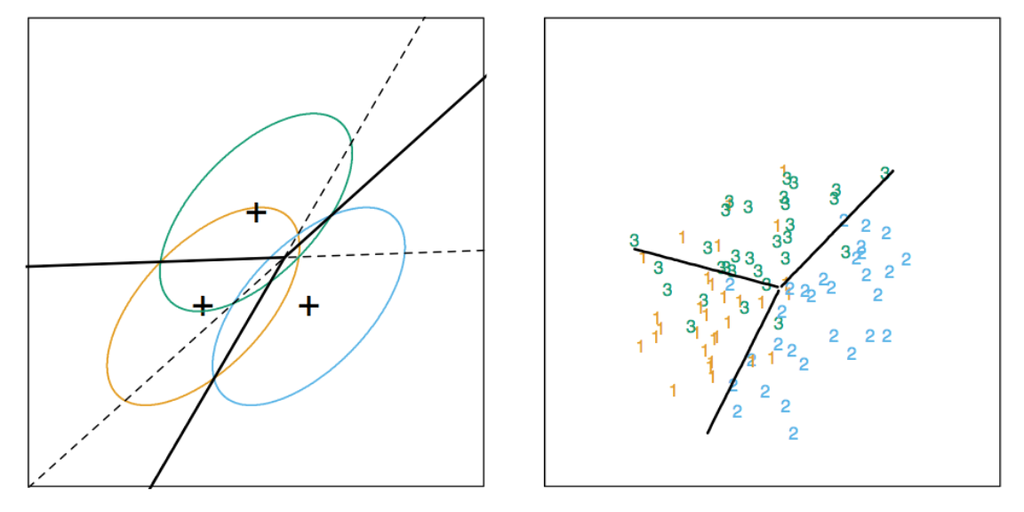

- **R Commands**
  - `lda<-train(outcome ~ predictors, data=training, method="lda")` = constructs a linear discriminant analysis model on the predictors with the provided training data
  - `predict(lda, test)` = applies the LDA model to test data and return the prediction results in data frame
  - *example: `caret` package*

```r
# load data
data(iris)
# create training and test sets
inTrain <- createDataPartition(y=iris$Species,p=0.7, list=FALSE)
training <- iris[inTrain,]
testing <- iris[-inTrain,]
# run the linear discriminant analysis on training data
lda <- train(Species ~ .,data=training,method="lda")
# predict test outcomes using LDA model
pred.lda <- predict(lda,testing)
# print results
pred.lda
```

```
##  [1] setosa     setosa     setosa     setosa     setosa     setosa
##  [7] setosa     setosa     setosa     setosa     setosa     setosa
## [13] setosa     setosa     setosa     versicolor versicolor versicolor
## [19] versicolor versicolor versicolor versicolor versicolor versicolor
## [25] versicolor versicolor versicolor versicolor versicolor versicolor
## [31] virginica  virginica  virginica  virginica  virginica  virginica
## [37] virginica  virginica  virginica  versicolor virginica  virginica
## [43] virginica  virginica  virginica
## Levels: setosa versicolor virginica
```

### Naive Bayes

- for predictors $X_1,\ldots,X_m$, we want to model $P(Y = k ~|~ X_1,\ldots,X_m)$
- by applying *Bayes’ Theorem*, we get
  $$P(Y = k ~|~ X_1,\ldots,X_m) = \frac{\pi_k P(X_1,\ldots,X_m~|~ Y=k)}{\sum_{\ell = 1}^K P(X_1,\ldots,X_m ~|~ Y=k) \pi_{\ell}}$$
- since the denominator is just a sum (constant), we can rewrite the quantity as
  $$P(Y = k ~|~ X_1,\ldots,X_m) \propto \pi_k P(X_1,\ldots,X_m~|~ Y=k)$$
  or the probability is **proportional to** the numerator
  - **Note**: maximizing the numerator is the same as maximizing the ratio
- $\pi_k P(X_1,\ldots,X_m~|~ Y=k)$ can be rewritten as
  $$\begin{aligned}
  \pi_k P(X_1,\ldots,X_m~|~ Y=k) & = \pi_k P(X_1 ~|~ Y = k)P(X_2,\ldots,X_m ~|~ X_1,Y=k) \\
  & = \pi_k P(X_1 ~|~ Y = k) P(X_2 ~|~ X_1, Y=k) P(X_3,\ldots,X_m ~|~ X_1,X_2, Y=k) \\
  & = \pi_k P(X_1 ~|~ Y = k) P(X_2 ~|~ X_1, Y=k)\ldots P(X_m~|~X_1\ldots,X_{m-1},Y=k) \\
  \end{aligned}$$
  where each variable has its own probability term that depends on all the terms before it
  - this is effectively indicating that each of the predictors may be dependent on other predictors
- however, if we make the assumption that all predictor variables are **independent** to each other, the quantity can be simplified to
  $$\pi_k P(X_1,\ldots,X_m~|~ Y=k) \approx \pi_k P(X_1 ~|~ Y = k) P(X_2 ~|~ Y = k)\ldots P(X_m ~|~,Y=k)$$
  which is effectively the product of the prior probability for $k$ and the probability of variables $X_1,\ldots,X_m$ given that $Y = k$
  - **Note**: the assumption is naive in that it is unlikely the predictors are completely independent of each other, but this model still produces **useful** results particularly with **large number of binary/categorical variables**
    - text and document classification usually require large quantities of binary and categorical features
- **R Commands**
  - `nb <- train(outcome ~ predictors, data=training, method="nb")` = constructs a naive Bayes model on the predictors with the provided training data
  - `predict(nb, test)` = applies the naive Bayes model to test data and return the prediction results in data frame
  - *example: `caret` package*

```r
# using the same data from iris, run naive Bayes on training data
nb <- train(Species ~ ., data=training,method="nb")
# predict test outcomes using naive Bayes model
pred.nb <- predict(nb,testing)
# print results
pred.nb
```

```
##  [1] setosa     setosa     setosa     setosa     setosa     setosa
##  [7] setosa     setosa     setosa     setosa     setosa     setosa
## [13] setosa     setosa     setosa     versicolor versicolor versicolor
## [19] versicolor versicolor versicolor versicolor versicolor versicolor
## [25] versicolor versicolor versicolor versicolor versicolor versicolor
## [31] virginica  virginica  virginica  virginica  versicolor virginica
## [37] virginica  virginica  virginica  versicolor virginica  virginica
## [43] virginica  virginica  virginica
## Levels: setosa versicolor virginica
```

### Compare Results for LDA and Naive Bayes

- linear discriminant analysis and naive Bayes generally produce similar results for small data sets
- for our example data from `iris` data set, we can compare the prediction the results from the two models

```r
# tabulate the prediction results from LDA and naive Bayes
table(pred.lda,pred.nb)
```

```
##             pred.nb
## pred.lda     setosa versicolor virginica
##   setosa         15          0         0
##   versicolor      0         16         0
##   virginica       0          1        13
```

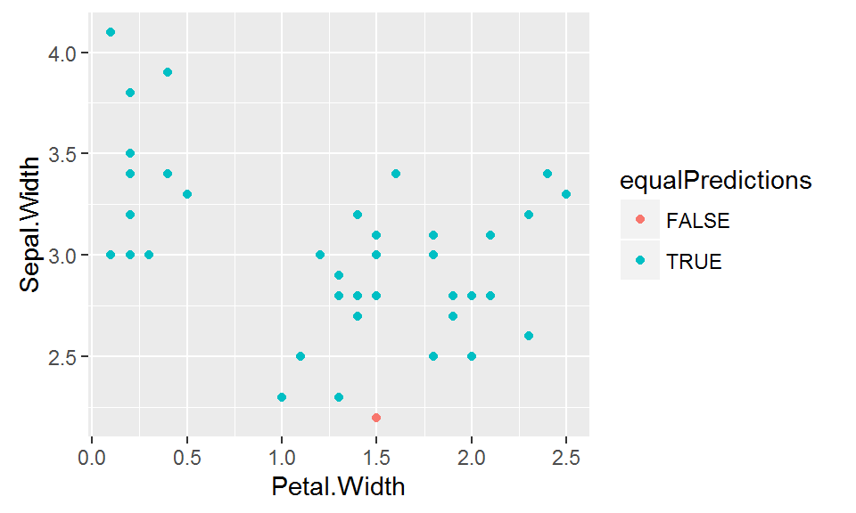

```r
# create logical variable that returns TRUE for when predictions from the two models match
equalPredictions <- (pred.lda==pred.nb)
# plot the comparison
qplot(Petal.Width,Sepal.Width,colour=equalPredictions,data=testing)
```

- as we can see from above, only one data point, which is located inbetween the two classes is predicted differently by the two models

$\pagebreak$

## Model Selection

- the general behavior of the errors of the training and test sets are as follows
  - as the number of predictors used increases (or model complexity), the error for the prediction model on *training* set **always decreases**
  - the error for the prediction model on *test* set **decreases first and then increases** as number of predictors used approaches the total number of predictors available

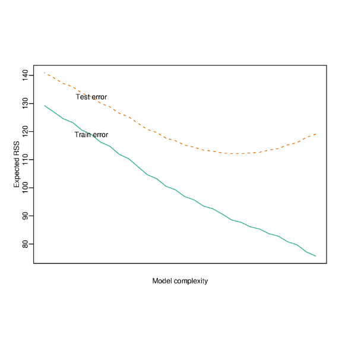

- this is expected since as more predictors used, the model is more likely to *overfit* the training data
- **goal** in selecting models = *avoid overfitting* on training data and *minimize error* on test data
- *approaches*
  - split samples
  - decompose expected prediction error
  - hard thresholding for high-dimensional data
  - regularization for regression
    - ridge regression
    - lasso regression
- *problems*
  - time/computational complexity limitations
  - high dimensional

### Example: Training vs Test Error for Combination of Predictors

- **Note**: the code for this example comes from [Hector Corrada Bravo’s Practical Machine Learning Course](http://www.cbcb.umd.edu/~hcorrada/PracticalML/src/selection.R)
- to demonstrate the behavior of training and test errors, the `prostate` dataset from *Elements of Statistical Learning* is used
- all combinations of predictors are used to produce prediction models, and Residual Squared Error (RSS) is calculated for all models on both the training and test sets

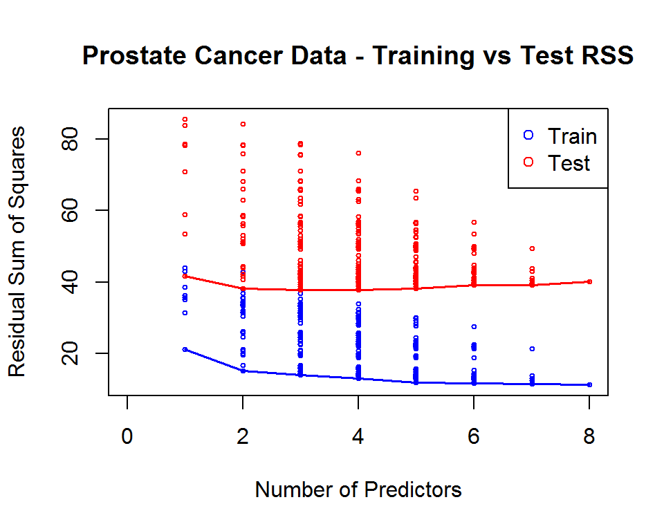

```r
# load data and set seed
data(prostate); set.seed(1)
# define outcome y and predictors x
covnames <- names(prostate[-(9:10)])
y <- prostate$lpsa; x <- prostate[,covnames]
# create test set predictors and outcomes
train.ind <- sample(nrow(prostate), ceiling(nrow(prostate))/2)
y.test <- prostate$lpsa[-train.ind]; x.test <- x[-train.ind,]
# create training set predictors and outcomes
y <- prostate$lpsa[train.ind]; x <- x[train.ind,]
# p = number of predictors
p <- length(covnames)
# initialize the list of residual sum squares
rss <- list()
# loop through each combination of predictors and build models
for (i in 1:p) {
    # compute matrix for p choose i predictors for i = 1...p (creates i x p matrix)
    Index <- combn(p,i)
    # calculate residual sum squares of each combination of predictors
    rss[[i]] <- apply(Index, 2, function(is) {
        # take each combination (or column of Index matrix) and create formula for regression
        form <- as.formula(paste("y~", paste(covnames[is], collapse="+"), sep=""))
        # run linear regression with combination of predictors on training data
        isfit <- lm(form, data=x)
        # predict outcome for all training data points
        yhat <- predict(isfit)
        # calculate residual sum squares for predictions on training data
        train.rss <- sum((y - yhat)^2)
        # predict outcome for all test data points
        yhat <- predict(isfit, newdata=x.test)
        # calculate residual sum squares for predictions on test data
        test.rss <- sum((y.test - yhat)^2)
        # store each pair of training and test residual sum squares as a list
        c(train.rss, test.rss)
    })
}
# set up plot with labels, title, and proper x and y limits
plot(1:p, 1:p, type="n", ylim=range(unlist(rss)), xlim=c(0,p),
    xlab="Number of Predictors", ylab="Residual Sum of Squares",
    main="Prostate Cancer Data - Training vs Test RSS")
# add data points for training and test residual sum squares
for (i in 1:p) {
    # plot training residual sum squares in blue
    points(rep(i, ncol(rss[[i]])), rss[[i]][1, ], col="blue", cex = 0.5)
    # plot test residual sum squares in red
    points(rep(i, ncol(rss[[i]])), rss[[i]][2, ], col="red", cex = 0.5)
}
# find the minimum training RSS for each combination of predictors
minrss <- sapply(rss, function(x) min(x[1,]))
# plot line through the minimum training RSS data points in blue
lines((1:p), minrss, col="blue", lwd=1.7)
# find the minimum test RSS for each combination of predictors
minrss <- sapply(rss, function(x) min(x[2,]))
# plot line through the minimum test RSS data points in blue
lines((1:p), minrss, col="red", lwd=1.7)
# add legend
legend("topright", c("Train", "Test"), col=c("blue", "red"), pch=1)
```

- from the above, we can clearly that test RSS error approaches the minimum at around 3 predictors and increases slightly as more predictors are used

### Split Samples

- the best method to pick predictors/model is to split the given data into different test sets
- **process**
  1. divide data into training/test/validation sets (60 - 20 - 20 split)
  2. train all competing models on the training data
  3. apply the models on validation data and choose the best performing model
  4. re-split data into training/test/validation sets and repeat steps 1 to 3
  5. apply the overall best performing model on test set to appropriately assess performance on new data
- **common problems**
  - limited data = if not enough data is available, it may not be possible to produce a good model fit after splitting the data into 3 sets
  - computational complexity = modeling with all subsets of models can be extremely taxing in terms of computations, especially when a large number of predictors are available

### Decompose Expected Prediction Error

- the outcome $Y_i$ can be modeled by
  $$Y_i = f(X_i) + \epsilon_i$$
  where $\epsilon_i$ = error term
- the **expected prediction error** is defined as
  $$EPE(\lambda) = E\left[\left(Y - \hat{f}_{\lambda}(X)\right)^2\right]$$
  where $\lambda$ = specific set of tuning parameters
- estimates from the model constructed with training data can be denoted as $\hat{f}_{\lambda}(x^*)$ where $X = x^*$ is the new data point that we would like to predict at
- the expected prediction error is as follows
  $$\begin{aligned}
  E\left[\left(Y - \hat{f}_{\lambda}(x^*)\right)^2\right] & = \sigma^2 + \left(E[\hat{f}_{\lambda}(x^*)] - f(x^*)\right)^2 + E\left[\hat{f}_{\lambda}(x^*) - E[\hat{f}_{\lambda}(x^*)]\right]^2\\
  & = \mbox{Irreducible Error} + \mbox{Bias}^2 + \mbox{Variance}\\
  \end{aligned}$$
  - **goal of prediction model** = minimize overall expected prediction error
  - irreducible error = noise inherent to the data collection process $\rightarrow$ cannot be reduced
  - bias/variance = can be traded in order to find optimal model (least error)

### Hard Thresholding

- if there are more predictors than observations (high-dimensional data), linear regressions will only return coefficients for some of the variables because there’s not enough data to estimate the rest of the parameters
  - conceptually, this occurs because the design matrix that the model is based on cannot be inverted
  - **Note**: ridge regression can help address this problem
- **hard thresholding** can help estimate the coefficients/model by taking subsets of predictors and building models
- **process**
  - model the outcome as
    $$Y_i = f(X_i) + \epsilon_i$$
    where $\epsilon_i$ = error term
  - assume the prediction estimate has a linear form
    $$\hat{f}_{\lambda}(x) = x'\beta$$
    where only $\lambda$ coefficients for the set of predictors $x$ are *nonzero*
  - after setting the value of $\lambda$, compute models using all combinations of $\lambda$ variables to find which variables’ coefficients should be set to be zero
- **problem**
  - computationally intensive
- *example*
  - as we can see from the results below, some of the coefficients have values of `NA`

```r
# load prostate data
data(prostate)
# create subset of observations with 10 variables
small = prostate[1:5,]
# print linear regression
lm(lpsa ~ .,data =small)
```

```
##
## Call:
## lm(formula = lpsa ~ ., data = small)
##
## Coefficients:
## (Intercept)       lcavol      lweight          age         lbph
##     9.60615      0.13901     -0.79142      0.09516           NA
##         svi          lcp      gleason        pgg45    trainTRUE
##          NA           NA     -2.08710           NA           NA
```

### Regularized Regression Concept ([Resource](http://www.cbcb.umd.edu/~hcorrada/PracticalML/pdf/lectures/selection.pdf))

- **regularized regression** = fit a regression model and adjust for the large coefficients in attempt to help with bias/variance trade-off or model selection
  - when running regressions unconstrained (without specifying any criteria for coefficients), the model may be susceptible to high variance (coefficients explode $\rightarrow$ very large values) if there are variables that are highly correlated
  - controlling/regularizing coefficients may slightly *increase bias* (lose a bit of prediction capability) but will *reduce variance* and improve the prediction error
  - however, this approach may be very demanding computationally and generally does not perform as well as random forest/boosting
- **Penalized Residual Sum of Squares (PRSS)** is calculated by adding a penalty term to the prediction squared error
  $$PRSS(\beta) = \sum_{j=1}^n (Y_j - \sum_{i=1}^m \beta_{1i} X_{ij})^2 + P(\lambda; \beta)$$
  - penalty shrinks coefficients if their values become too large
  - penalty term is generally used to reduce complexity and variance for the model, while respecting the structure of the data/relationship
- *example: co-linear variables*
  - given a linear model,
    $$Y = \beta_0 + \beta_1 X_1 + \beta_2 X_2 + \epsilon$$
    where $X_1$ and $X_2$ are nearly perfectly correlated (co-linear)
  - the model can then be approximated by this model by omitting $X_2$, so the model becomes
    $$Y = \beta_0 + (\beta_1 + \beta_2)X_1 + \epsilon$$
  - with the above model, we can get a good estimate of $Y$
    - the estimate of $Y$ will be biased
    - but the variance of the prediction may be reduced

### Regularized Regression - Ridge Regression

- the penalized residual sum of squares (PRSS) takes the form of
  $$PRSS(\beta_j) = \sum_{i=1}^N \left(y_i - \beta_0 - \sum_{j=1}^p x_{ij}\beta_j \right)^2 + \lambda \sum_{j=1}^p \beta_j^2$$
- this is equivalent to solving the equation
  $$PRSS(\beta_j) = \sum_{i=1}^N \left(y_i - \beta_0 - \sum_{j=1}^p x_{ij}\beta_j \right)^2$$
  subject to constraint $\sum_{j=1}^p \beta_j^2 \leq s$ where $s$ is inversely proportional to $\lambda$
  - if the coefficients $\beta_j$ are large in value, the term $\sum_{j=1}^p \beta_j^2$ will cause the overall PRSS value to increase, leading to worse models
  - the presence of the term thus requires some of the coefficients to be small
- inclusion of $\lambda$ makes the problem *non-singular* even if $X^TX$ is not invertible
  - this means that even in cases where there are more predictors than observations, the coefficients of the predictors can still be estimated
- $\lambda$ = tuning parameter
  - controls size of coefficients or the amount of regularization
  - as $\lambda \rightarrow 0$, the result approaches the least square solution
  - as $\lambda \rightarrow \infty$, all of the coefficients receive large penalties and the conditional coefficients $\hat{\beta}_{\lambda=\infty}^{ridge}$ approaches zero collectively
  - $\lambda$ should be carefully chosen through cross-validation/other techniques to find the optimal tradeoff of bias for variance
  - **Note**: it is important realize that all coefficients (though they may be shrunk to very small values) will **still be included** in the model when applying ridge regression
- **R Commands**
  - [`MASS` package] `ridge<-lm.ridge(outcome ~ predictors, data=training, lambda=5)` = perform ridge regression with given outcome and predictors using the provided $\lambda$ value
    - **Note**: the predictors are **centered and scaled first** before the regression is run
    - `lambda=5` = tuning parameter
    - `ridge$xm` = returns column/predictor mean from the data
    - `ridge$scale` = returns the scaling performed on the predictors for the ridge regression
      - **Note**: all the variables are divided by the biased standard deviation $\sum (X_i - \bar X_i) / n$
    - `ridge$coef` = returns the conditional coefficients, $\beta_j$ from the ridge regression
    - `ridge$ym` = return mean of outcome
  - `caret` package `train(outcome ~ predictors, data=training, method="ridge", lambda=5)` = perform ridge regression with given outcome and predictors
    - `preProcess=c("center", "scale")` = centers and scales the predictors before the model is built
      - **Note**: this is generally a good idea for building ridge regressions
    - `lambda=5` = tuning parameter
  - `caret` package `train(outcome ~ predictors, data=training, method="foba", lambda=5, k=4)` = perform ridge regression with variable selection
    - `lambda=5` = tuning parameter
    - `k=4` = number of variables that should be retained
      - this means that `length(predictors)-k` variables will be eliminated
  - `caret` package `predict(model,test)` = use the model to predict on test set $\rightarrow$ similar to all other `caret` algorithms
- *example: ridge coefficient paths vs $\lambda$*
  - using the same `prostate` dataset, we will run ridge regressions with different values of $\lambda$ and find the optimum $\lambda$ value that minimizes test RSS

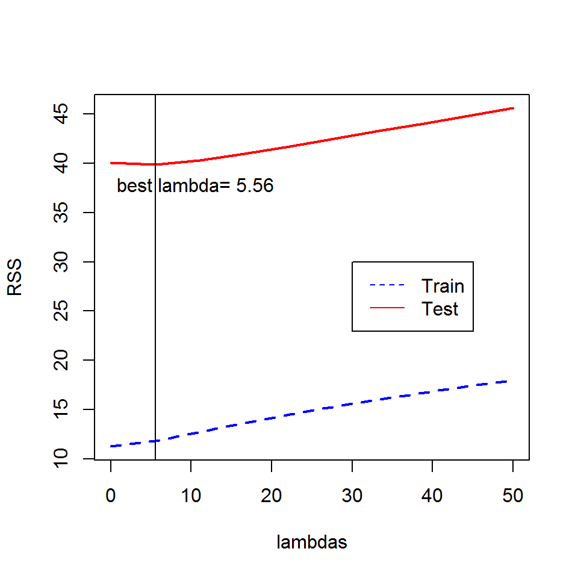

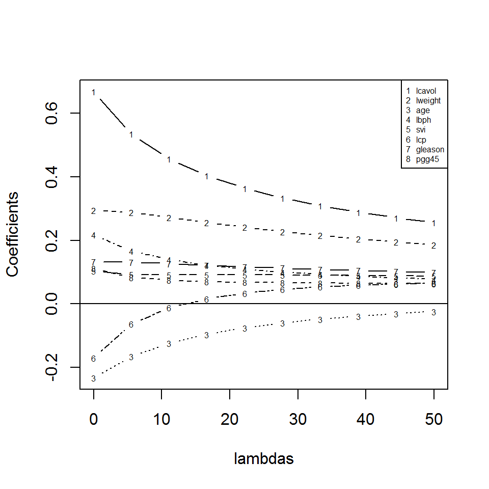

### Regularized Regression - LASSO Regression

- LASSO (least absolute shrinkage and selection operator) was introduced by Tibshirani (Journal of the Royal Statistical Society 1996)
- similar to **ridge**, with slightly different penalty term
- the penalized residual sum of squares (PRSS) takes the form of
  $$PRSS(\beta_j) = \sum_{i=1}^N \left(y_i - \beta_0 - \sum_{j=1}^p x_{ij}\beta_j \right)^2 + \lambda \sum_{j=1}^p |\beta_j|$$
- this is equivalent to solving the equation
  $$PRSS(\beta_j) = \sum_{i=1}^N \left(y_i - \beta_0 - \sum_{j=1}^p x_{ij}\beta_j \right)^2$$
  subject to constraint $\sum_{j=1}^p |\beta_j| \leq s$ where $s$ is inversely proportional to $\lambda$
- $\lambda$ = tuning parameter
  - controls size of coefficients or the amount of regularization
  - large values of $\lambda$ will set some coefficient equal to zero
    - **Note**: LASSO effectively performs model selection (choose subset of predictors) while shrinking other coefficients, where as Ridge only shrinks the coefficients
- **R Commands**
  - [`lars` package] `lasso<-lars(as.matrix(x), y, type="lasso", trace=TRUE)` = perform lasso regression by adding predictors one at a time (or setting some variables to 0)
    - **Note**: the predictors are **centered and scaled first** before the regression is run
    - `as.matrix(x)` = the predictors must be in matrix/dataframe format
    - `trace=TRUE` = prints progress of the lasso regression
    - `lasso$lambda` = return the $\lambda$s used for each step of the lasso regression
    - `plot(lasso)` = prints plot that shows the progression of the coefficients as they are set to zero one by one
    - `predit.lars(lasso, test)` = use the lasso model to predict on test data
      - **Note**: more information/documentation can be found in `?predit.lars`
  - [`lars` package] `cv.lars(as.matrix(x), y, K=10, type="lasso", trace=TRUE)` = computes K-fold cross-validated mean squared prediction error for lasso regression
    - effectively the `lars` function is run `K` times with each of the folds to estimate the
    - `K=10` = create 10-fold cross validation
    - `trace=TRUE` = prints progress of the lasso regression
  - [`enet` package] `lasso<-enet(predictors, outcome, lambda = 0)` = perform elastic net regression on given predictors and outcome
    - `lambda=0` = default value for $\lambda$
      - **Note**: lasso regression is a special case of elastic net regression, and forcing `lambda=0` tells the function to fit a lasso regression
    - `plot(lasso)` = prints plot that shows the progression of the coefficients as they are set to zero one by one
    - `predict.ent(lasso, test)`= use the lasso model to predict on test data
  - `caret` package `train(outcome ~ predictors, data=training, method="lasso")` = perform lasso regression with given outcome and predictors
    - **Note**: outcome and predictors must be in the same dataframe
    - `preProcess=c("center", "scale")` = centers and scales the predictors before the model is built
      - **Note**: this is generally a good idea for building lasso regressions
  - `caret` package `train(outcome~predictors,data=train,method="relaxo",lambda=5,phi=0.3)` = perform relaxed lasso regression on given predictors and outcome
    - `lambda=5` = tuning parameter
    - `phi=0.3` = relaxation parameter
      - `phi=1` corresponds to the regular Lasso solutions
      - `phi=0` computes the OLS estimates on the set of variables selected by the Lasso
  - `caret` package `predict(model,test)` = use the model to predict on test set $\rightarrow$ similar to all other `caret` algorithms
- *example: `lars` package*

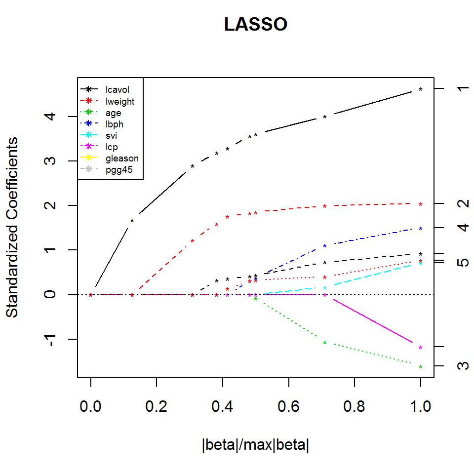

```r
# load lars package
library(lars)
# perform lasso regression
lasso.fit <- lars(as.matrix(x), y, type="lasso", trace=TRUE)
# plot lasso regression model
plot(lasso.fit, breaks=FALSE, cex = 0.75)
# add legend
legend("topleft", covnames, pch=8, lty=1:length(covnames),
    col=1:length(covnames), cex = 0.6)
```

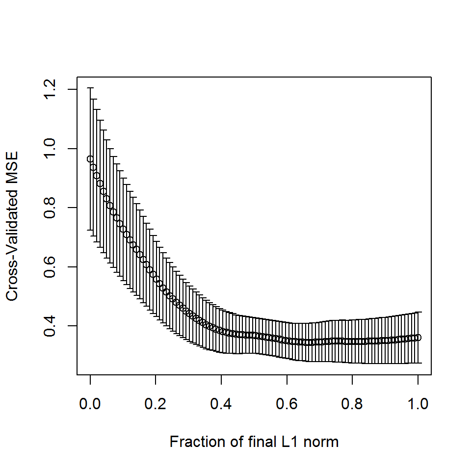

```r
# plots the cross validation curve
lasso.cv <- cv.lars(as.matrix(x), y, K=10, type="lasso", trace=TRUE)
```

$\pagebreak$

## Combining Predictors

- **combining predictors** = also known as [*ensembling methods in learning*](http://en.wikipedia.org/wiki/Ensemble_learning), combine classifiers by averaging/voting to improve accuracy (generally)
  - this reduces interpretability and increases computational complexity
  - boosting/bagging/random forest algorithms all use this idea, except all classifiers averaged are of the same type
- Netflix Competition was won by a team that blended together 107 machine learning algorithms, Heritage Health Prize was also won by a combination of algorithms
  - **Note**: the winning algorithm for Netflix was not used because it was too computationally complex/intensive, so the trade-off between accuracy and scalability is very important
- **approach**
  - combine similar classifiers using bagging/boosting/random forest
  - combine different classifiers using model stacking/ensembling
    - build an odd number of models (we need an odd number for the majority vote to avoid ties)
    - predict with each model
    - combine the predictions and predict the final outcome by majority vote
- **process: simple model ensembling**
  1. *build multiple models* on the training data set
  2. use the models to *predict* on the training/test set
     - *predict on training* if the data was divided to only training/test sets
     - *predict on test* if the data was divided into training/test/validation sets
  3. combine the prediction results from each model and the true results for the training/test set into a *new data frame*
     - one column for each model
     - add the true outcome from the training/test set as a separate column
  4. train the new data frame with a *new model* the true outcome as the outcome, and the predictions from various models as predictors
  5. use the combined model fit to predict results on the training/test data
     - calculate the RMSE for all models, including combined fit, to evaluate the accuracy of the different models
     - **Note**: the RMSE for the combined fit should generally be **lower** than the the rest of the models
  6. to predict on the final test/validation set, use all the initial models to predict on the data set first to *recreate a prediction data frame* for the test/validation set like in *step 3*
     - one column for each model, no truth column this time
  7. *apply the combined fit* on the combined prediction data frame to get the final resultant predictions

### Example - Majority Vote

- suppose we have 5 independent classifiers/models
- each has 70% accuracy
- **majority vote accuracy (mva)** = probability of the majority of the models achieving 70% at the same time

- with 101 classifiers, the majority vote accuracy becomes 99.9%

### Example - Model Ensembling

```r
# set up data
inBuild <- createDataPartition(y=Wage$wage,p=0.7, list=FALSE)
validation <- Wage[-inBuild,]; buildData <- Wage[inBuild,]
inTrain <- createDataPartition(y=buildData$wage,p=0.7, list=FALSE)
training <- buildData[inTrain,]; testing <- buildData[-inTrain,]
# train the data using both glm and random forest models
glm.fit <- train(wage ~.,method="glm",data=training)
rf.fit <- train(wage ~.,method="rf",data=training,
    trControl = trainControl(method="cv"),number=3)
# use the models to predict the results on the testing set
glm.pred.test <- predict(glm.fit,testing)
rf.pred.test <- predict(rf.fit,testing)
# combine the prediction results and the true results into new data frame
combinedTestData <- data.frame(glm.pred=glm.pred.test,
    rf.pred = rf.pred.test,wage=testing$wage)
# run a Generalized Additive Model (gam) model on the combined test data
comb.fit <- train(wage ~.,method="gam",data=combinedTestData)
# use the resultant model to predict on the test set
comb.pred.test <- predict(comb.fit, combinedTestData)
# use the glm and rf models to predict results on the validation data set
glm.pred.val <- predict(glm.fit,validation)
rf.pred.val <- predict(rf.fit,validation)
# combine the results into data frame for the comb.fit
combinedValData <- data.frame(glm.pred=glm.pred.val,rf.pred=glm.pred.val)
# run the comb.fit on the combined validation data
comb.pred.val <- predict(comb.fit,combinedValData)
# tabulate the results - test data set RMSE Errors
rbind(test = c(glm = sqrt(sum((glm.pred.test-testing$wage)^2)),
        rf = sqrt(sum((rf.pred.test-testing$wage)^2)),
        combined = sqrt(sum((comb.pred.test-testing$wage)^2))),
    # validation data set RMSE Errors
    validation = c(sqrt(sum((glm.pred.val-validation$wage)^2)),
        sqrt(sum((rf.pred.val-validation$wage)^2)),
        sqrt(sum((comb.pred.val-validation$wage)^2))))
```

```
##                  glm        rf  combined
## test        858.7074  885.1711  848.8167
## validation 1061.0891 1086.6040 1056.6559
```

$\pagebreak$

## Forecasting

- **forecasting** = typically used with time series, predict one or more observations into the future
  - data are dependent over time so subsampling/splitting data into training/test is more complicated and must be done very carefully
- specific patterns need to be considered for time series data (*time series decomposition*)
  - **trend** = long term increase/decrease in data
  - **seasonal** = patterns related to time of week/month/year/etc
  - **cyclic** = patterns that rise/fall periodically
- **Note**: issues that arise from time series are similar to those from spatial data
  - dependency between nearby observations
  - location specific effects
- all standard predictions models can be used but requires more consideration
- **Note**: more detailed tutorial can be found in [Rob Hyndman’s Forecasting: principles and practice](https://www.otexts.org/fpp/)
- **considerations for interpreting results**
  - unrelated time series can often seem to be correlated with each other (*spurious correlations*)
  - geographic analysis may exhibit similar patterns due to population distribution/concentrations
  - extrapolations too far into future can be dangerous as they can produce in insensible results
  - dependencies over time (seasonal effects) should be examined and isolated from the trends
- **process**
  - ensure the data is a time series data type
  - split data into training and test sets
    - both must have consecutive time points
  - choose forecast approach (SMA - `ma` vs EMA - `ets`, see below) and apply corresponding functions to training data
  - apply constructed forecast model to test data using `forecast` function
  - evaluate accuracy of forecast using `accuracy` function
- **approaches**
  - *simple moving averages* = prediction will be made for a time point by averaging together values from a number of prior periods
    $$Y_{t}=\frac{1}{2*k+1}\sum_{j=-k}^k {y_{t+j}}$$
  - *exponential smoothing/exponential moving average* = weight time points that are closer to point of prediction than those that are further away
    $$\hat{y}_{t+1} = \alpha y_t + (1-\alpha)\hat{y}_{t-1}$$
    - **Note**: many different methods of exponential smoothing are available, more information can be found [here](https://www.otexts.org/fpp/7/6)

### R Commands and Examples

- `quantmod` package can be used to pull trading/price information for publicly traded stocks
  - `getSymbols("TICKER", src="google", from=date, to=date)` = gets the *daily* high/low/open/close price and volume information for the specified stock ticker
    - returns the data in a data frame under the stock ticker’s name
    - `"TICKER"` = ticker of the stock you are attempting to pull information for
    - `src="google"` = get price/volume information from Google finance
      - default source of information is Yahoo Finance
    - `from` and `to` = from and to dates for the price/volume information
      - both arguments must be specified with `date` objects
    - **Note**: more information about how to use `getSymbols` can be found in the documentation `?getSymbols`
  - `to.monthly(GOOG)` = converts stock data to monthly time series from daily data
    - the function aggregates the open/close/high/low/volume information for each day into monthly data
    - `GOOG` = data frame returned from `getSymbols` function
    - **Note**: `?to.period` contains documentation for converting time series to OHLC (open high low close) series
  - `googOpen<-Op(GOOG)` = returns the opening price from the stock data frame
    - `Cl(), Hi(), Lo()` = returns the close, high and low price from the stock data frame
  - `ts(googOpen, frequency=12)` = convert data to a time series with `frequency` observations per time unit
    - `frequency=12` = number of observations per unit time (12 in this case because there are 12 months in each year $\rightarrow$ converts data into *yearly* time series)
- `decompose(ts)` = decomposes time series into trend, seasonal, and irregular components by using moving averages
  - `ts` = time series object
- `window(ts, start=1, end=6)` = subsets the time series at the specified starting and ending points
  - `start` and `end` arguments must correspond to the **time unit** rather than the *index*
    - for instance, if the `ts` is a yearly series (`frequency = 12`), `start`/`end` should correspond to the row numbers or year (each year has 12 observations corresponding to the months)
    - `c(1, 7)` can be used to specify the element of a particular year (in this case, July of the first year/row)
    - **Note**: you can use 9.5 or any decimal as values for `start`/`end`, and the closest element (June of the 9th year in this case) will be used
    - **Note**: `end=9-0.01` can be used a short cut to specify “up to 9”, since `end = 9` will include the first element of the 9th row
- `forecast` package can be used for forecasting time series data
  - `ma(ts, order=3)` = calculates the simple moving average for the order specified
    - `order=3` = order of moving average smoother, effectively the number of values that should be used to calculate the moving average
  - `ets(train, model="MMM")` = runs exponential smoothing model on training data
    - `model = "MMM"` = method used to create exponential smoothing
      - **Note**: more information can be found at `?ets` and the corresponding model chart is [here](https://www.otexts.org/fpp/7/6)
  - `forecast(ts)` = performs forecast on specified time series and returns 5 columns: forecast values, high/low 80 confidence intervals bounds, high/low 95 percent interval bounds
    - `plot(forecast)` = plots the forecast object, which includes the training data, forecast values for test periods, as well as the 80 and 95 percent confidence interval regions
  - `accuracy(forecast, testData)` = returns the accuracy metrics (RMSE, etc.) for the forecast model
- `quandl` package is also used for finance-related predictions
- *example: decomposed time series*

```r
# load quantmod package
library(quantmod);
# specify to and from dates
from.dat <- as.Date("01/01/00", format="%m/%d/%y")
to.dat <- as.Date("3/2/15", format="%m/%d/%y")
# get data for AAPL from Google Finance for the specified dates
getSymbols("AAPL", src="google", from = from.dat, to = to.dat)
```

```
## [1] "AAPL"
```

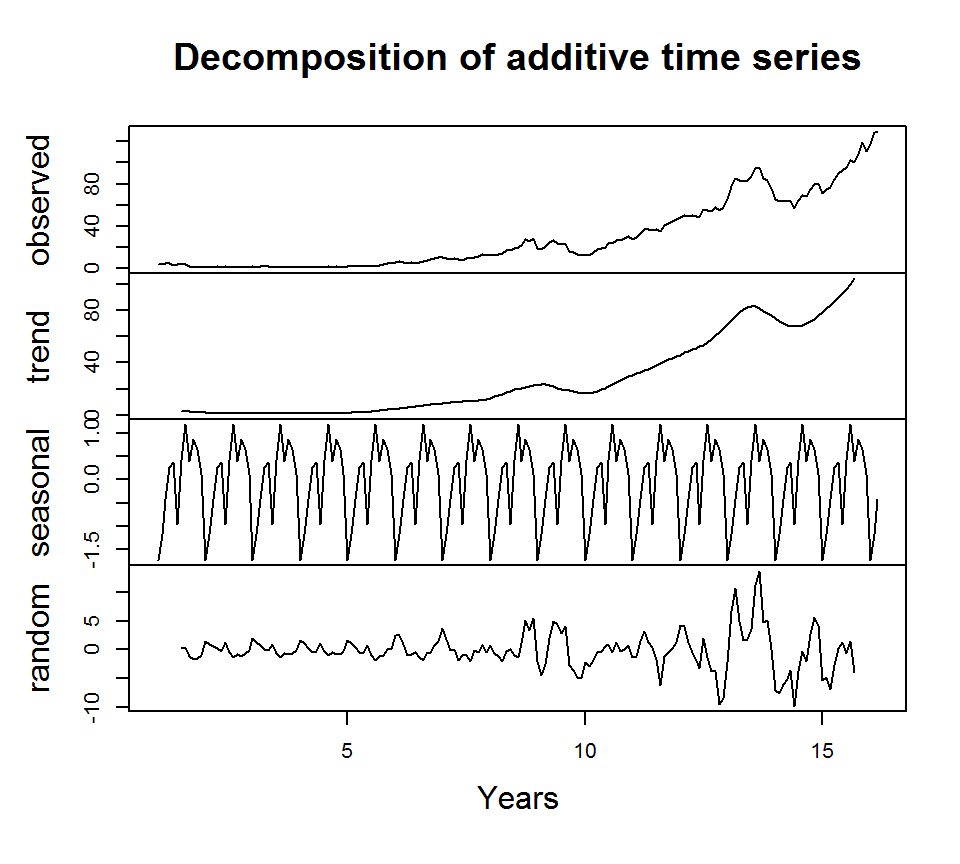

```r
# convert the retrieved daily data to monthly data
mAAPL <- to.monthly(AAPL)
# extract the closing price and convert it to yearly time series (12 observations per year)
ts <- ts(Cl(mAAPL), frequency = 12)
# plot the decomposed parts of the time series
plot(decompose(ts),xlab="Years")
```

- *example: forecast*

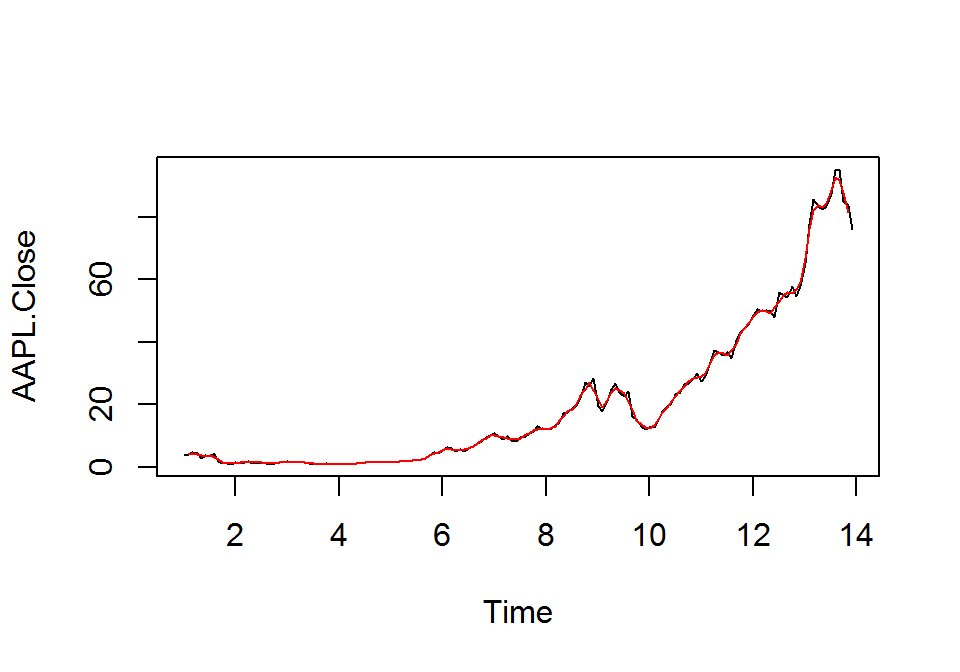

```r
# load forecast library
library(forecast)
# find the number of rows (years)
rows <- ceiling(length(ts)/12)
# use 90% of the data to create training set
ts.train <- window(ts, start = 1, end = floor(rows*.9)-0.01)
# use the rest of data to create test set
ts.test <- window(ts, start = floor(rows*.9))
# plot the training set
plot(ts.train)
# add the moving average in red
lines(ma(ts.train,order=3),col="red")
```

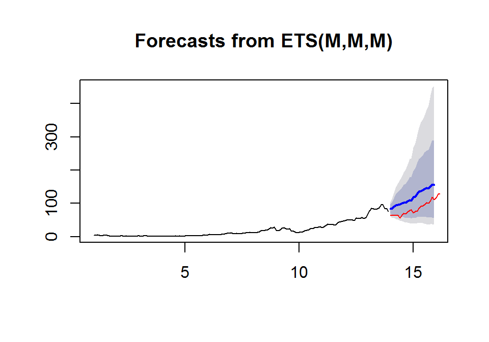

```r
# compute the exponential smoothing average
ets <- ets(ts.train,model="MMM")
# construct a forecasting model using the exponential smoothing function
fcast <- forecast(ets)
# plot forecast and add actual data in red
plot(fcast); lines(ts.test,col="red")
```

```r
# print the accuracy of the forecast model
accuracy(fcast,ts.test)
```

```
##                       ME      RMSE       MAE        MPE     MAPE      MASE
## Training set  -0.1009703  2.603752  1.432924  -2.127817 10.50342 0.1752366
## Test set     -38.0408813 39.138040 38.040881 -47.852849 47.85285 4.6521333
##                    ACF1 Theil's U
## Training set 0.09343665        NA
## Test set     0.71578084  7.274911
```

$\pagebreak$

## Unsupervised Prediction

- **supervised classification** = predicting outcome when we know what the different classifications are
  - *example*: predicting the type of flower (setosa, versicolor, or virginica) based on sepal width/length
- **unsupervised classification** = predicting outcome when we don’t know what the different classifications are
  - *example*: splitting all data for sepal width/length into different groups (cluster similar data together)
- **process**
  - provided that the labels for prediction/outcome are unknown, we first build clusters from observed data
    - creating clusters are not noiseless process, and thus may introduce higher variance/error for data
    - *K-means* is an example of a clustering approach
  - label the clusters
    - interpreting the clusters well (sensible vs non-sensible clusters) is incredibly challenging
  - build prediction model with the clusters as the outcome
    - all algorithms can be applied here
  - in new data set, we will predict the clusters labels
- unsupervised prediction is effectively a *exploratory technique*, so the resulting clusters should be carefully interpreted
  - clusters may be highly variable depending on the method through which the data is sample
- generally a good idea to create custom clustering algorithms for given data as it is **crucial** to define the process to identify clusters for interpretability and utility of the model
- unsupervised prediction = basic approach to [recommendation engines](http://en.wikipedia.org/wiki/Recommender_system), in which the tastes of the existing users are clustered and applied to new users

### R Commands and Examples

- `kmeans(data, centers=3)` = can be used to perform clustering from the provided data
  - `centers=3` = controls the number of clusters the algorithm should aim to divide the data into
- `cl_predict` function in `clue` package provides similar functionality

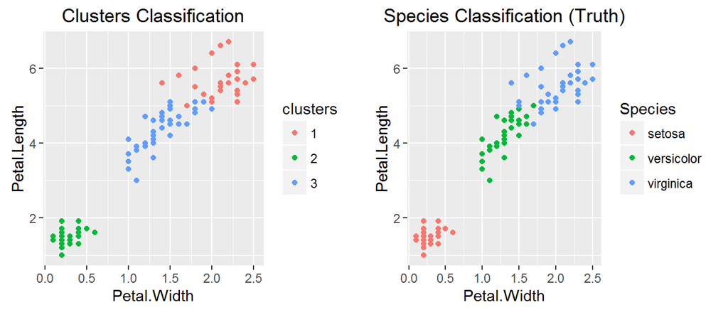

```r
# load iris data
data(iris)
# create training and test sets
inTrain <- createDataPartition(y=iris$Species,p=0.7, list=FALSE)
training <- iris[inTrain,]; testing <- iris[-inTrain,]
# perform k-means clustering for the data without the Species information
# Species = what the true clusters are
kMeans1 <- kmeans(subset(training,select=-c(Species)),centers=3)
# add clusters as new variable to training set
training$clusters <- as.factor(kMeans1$cluster)
# plot clusters vs Species classification
p1 <- qplot(Petal.Width,Petal.Length,colour=clusters,data=training) +
    ggtitle("Clusters Classification")
p2 <- qplot(Petal.Width,Petal.Length,colour=Species,data=training) +
    ggtitle("Species Classification (Truth)")
grid.arrange(p1, p2, ncol = 2)
```

- as we can see, there are three clear groups that emerge from the data
  - this is fairly close to the actual results from Species
  - we can compare the results from the clustering and Species classification by tabulating the values

```r
# tabulate the results from clustering and actual species
table(kMeans1$cluster,training$Species)
```

```
##
##     setosa versicolor virginica
##   1      0          1        25
##   2     35          0         0
##   3      0         34        10
```

- with the clusters determined, the training data can be trained on all predictors with the clusters from k-means as outcome

```r
# build classification trees using the k-means cluster
clustering <- train(clusters ~.,data=subset(training,select=-c(Species)),method="rpart")
```

- we can compare the prediction results on training set vs truth

```r
# tabulate the prediction results on training set vs truth
table(predict(clustering,training),training$Species)
```

```
##
##     setosa versicolor virginica
##   1      0          0        23
##   2     35          0         0
##   3      0         35        12
```

- similarly, we can compare the prediction results on test set vs truth

```r
# tabulate the prediction results on test set vs truth
table(predict(clustering,testing),testing$Species)
```

```
##
##     setosa versicolor virginica
##   1      0          0        11
##   2     15          0         0
##   3      0         15         4
```